# Assignment 2. Mastering data wrangling and visuals

Mathilde Diekema

10/14/2021

# Ticket sales for a swimming pool

How can we use transaction data to test whether a difference in the daily volume of sales can be found between summer and winter time? This case study uses the swim_work.csv dataset which can be found here: https://osf.io/jcxmk/. The data includes information on daily ticket sale of an outdoor swimming pool operating in Albuquerque (New Maxico, USA). The dataset has n = 2522 observations.

https://osf.io/s3ng2/ # Import libraries

```r
library(tidyverse)
library(stargazer)
library(Hmisc)
library(timeDate)
library(lubridate)
library(dplyr)
```

# Creating time features

#import data

```r
daily_agg <- read.csv(file = paste("swim_work.csv", sep = ""))%>%
  mutate(date = as.Date(date))
```

```r
# Day of Week (dow): 1 = Monday, 2 = Tuesday, 3 = Wednesday, 4 = Thursday, 5 = Friday, 6 = Saturday, 7 = Sunday
# Wekend: Satuday and Sunday

daily_agg <- daily_agg %>%
  mutate(year = year(date),
         quarter = quarter(date),
         month = factor(month(date)),
         day = day(date)) %>%
  mutate(dow = factor(lubridate::wday(date, week_start = getOption("lubridate.week.start", 1))))
```

# Define var for graphs

```r
# named date vars for graphs
mydays <- c("Mon","Tue","Wed",
            "Thu","Fri","Sat",
            "Sun")
daily_agg$dow_abb   <-factor(   mydays[daily_agg$dow],  levels=mydays)
daily_agg$month_abb <-factor(month.abb[daily_agg$month],levels=month.abb)
```

# Descriptive graphs

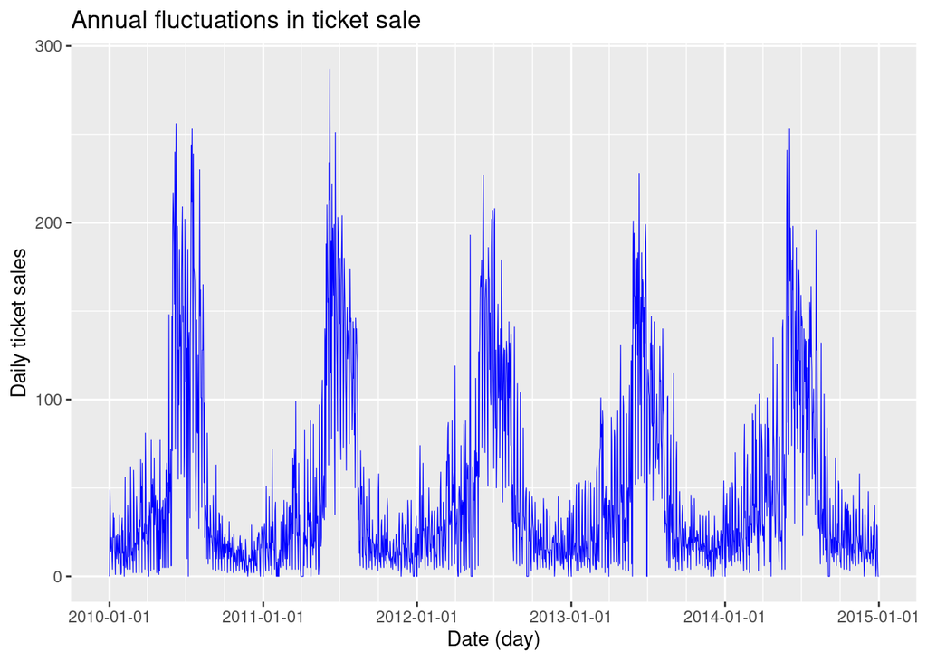

```r
color <- c("blue", "red", "green", "black")


g1<-ggplot(data=daily_agg[(daily_agg$year>=2010) & (daily_agg$year<=2014),], aes(x=date, y=QUANTITY)) +
  geom_line(size=0.2, color=color[1]) +
  ggtitle("Annual fluctuations in ticket sale ") +
  scale_x_date(breaks = as.Date(c("2010-01-01","2011-01-01","2012-01-01","2013-01-01","2014-01-01","2015-01-01")),
               minor_breaks = "3 months") +
  labs( x = "Date (day)", y="Daily ticket sales" ) +
  scale_color_discrete(name = "")
g1
```

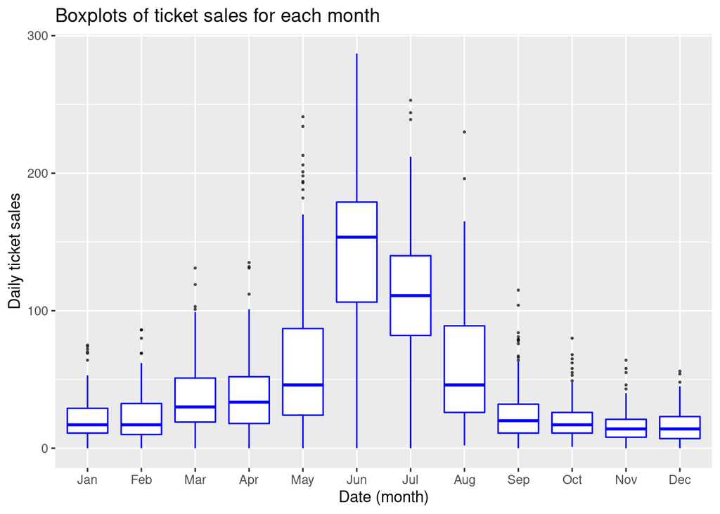

```r
g2<-ggplot(data=daily_agg, aes(x=month_abb, y=QUANTITY)) +
  ggtitle("Boxplots of ticket sales for each month") +
  labs( x = "Date (month)", y="Daily ticket sales" ) +
  geom_boxplot(color=color[1],outlier.color = color[4], outlier.alpha = 0.6, outlier.size = 0.4)
g2
```

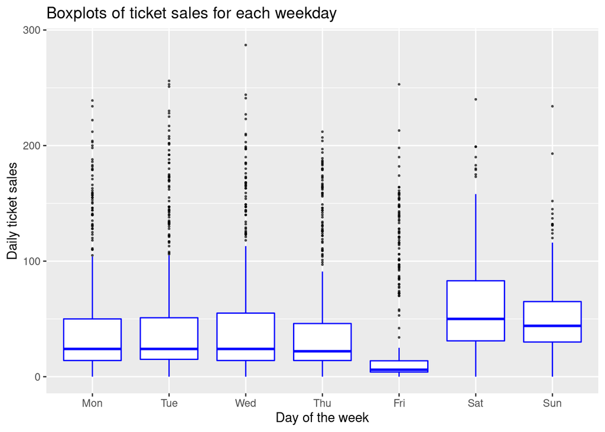

```r
g3<-ggplot(data=daily_agg, aes(x=dow_abb, y=QUANTITY)) +
  ggtitle("Boxplots of ticket sales for each weekday") +
  labs( x = "Day of the week", y="Daily ticket sales" ) +
  geom_boxplot(color=color[1],outlier.color = color[4], outlier.alpha = 0.6, outlier.size = 0.4)
  #geom_boxplot(color=color[1], outlier.shape = NA)
g3
```

We can see that there seems to be a difference in ticket sale between winter and summer. Also sales seem to depend on weekday. We calculate the difference between winter and summer for all randomly sampled weekdays:

# T-test

```r
#winter
winter <- daily_agg %>%
  filter(quarter == c(1, 4)) %>%
  select(dow, quarter, QUANTITY)
#divided by weekday
w_mon <- winter %>% filter(dow == 1)
w_tue <- winter %>% filter(dow == 2)
w_wed <- winter %>% filter(dow == 3)
w_thu <- winter %>% filter(dow == 4)
w_fri <- winter %>% filter(dow == 5)
w_sat <- winter %>% filter(dow == 6)
w_sun <- winter %>% filter(dow == 7)

#summer
summer <- daily_agg %>%
  filter(quarter == c(2, 3)) %>%
  select(dow, quarter, QUANTITY)
```

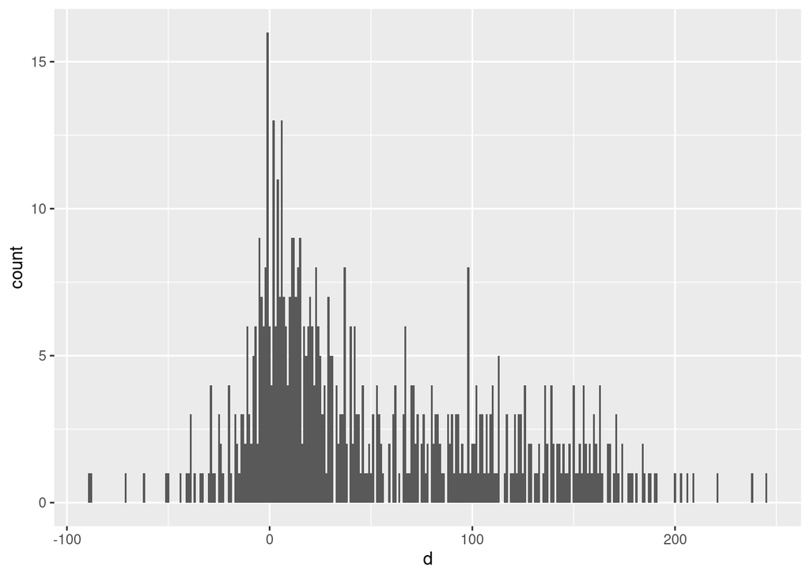

```r
#divided by weekday
s_mon <- summer %>% filter(dow == 1)
s_tue <- summer %>% filter(dow == 2)
s_wed <- summer %>% filter(dow == 3)
s_thu <- summer %>% filter(dow == 4)
s_fri <- summer %>% filter(dow == 5)
s_sat <- summer %>% filter(dow == 6)
s_sun <- summer %>% filter(dow == 7)

#Taking the minumum number of weekday
num_mon <- min(nrow(w_mon),nrow(s_mon))
num_tue <- min(nrow(w_tue),nrow(s_tue))
num_wed <- min(nrow(w_wed),nrow(s_wed))
num_thu <- min(nrow(w_thu),nrow(s_thu))
num_fri <- min(nrow(w_fri),nrow(s_fri))
num_sat <- min(nrow(w_sat),nrow(s_sat))
num_sun <- min(nrow(w_sun),nrow(s_sun))

set.seed(0)
# Randomly sampling within each weekday
w_qua <- c(sample_n(w_mon, num_mon)$QUANTITY, sample_n(w_tue, num_tue)$QUANTITY, sample_n(w_wed, num_wed)$QUANTITY, sample_n(w_thu, num_thu)$QUANTITY, sample_n(w_fri, num_fri)$QUANTITY, sample_n(w_sat, num_sat)$QUANTITY, sample_n(w_sun, num_sun)$QUANTITY)

# Randomly sampling within each weekday
s_qua <- c(sample_n(s_mon, num_mon)$QUANTITY, sample_n(s_tue, num_tue)$QUANTITY, sample_n(s_wed, num_wed)$QUANTITY, sample_n(s_thu, num_thu)$QUANTITY, sample_n(s_fri, num_fri)$QUANTITY, sample_n(s_sat, num_sat)$QUANTITY, sample_n(s_sun, num_sun)$QUANTITY)

#To make a paired comparison test, the difference between summer and winter is found
d <- s_qua-w_qua
sum_win_d <- data.frame(s_qua, w_qua, d)

#Testing for normal distribution of the data.
ggplot(data = sum_win_d, aes(x = d)) +
  geom_histogram(binwidth = 1)
```

```r
#calculating sd
(sd_win <-sd(w_qua))
```

```
## [1] 18.25606
```

```r
(sd_sum <-sd(s_qua))
```

```
## [1] 58.09204
```

```r
#Making a t-test
t.test(x = w_qua, y = s_qua, paired = T, var.equal = F)
```

```
##
##  Paired t-test
##
## data:  w_qua and s_qua
## t = -20.883, df = 620, p-value < 2.2e-16
## alternative hypothesis: true difference in means is not equal to 0
## 95 percent confidence interval:
##  -55.55111 -46.00123
## sample estimates:
## mean of the differences
##               -50.77617
```

The distribution of the difference in ticket sale between summer and winter is to some extent violating the normal distribution with a long right tail. Also the standard deviation was not the same in the two groups. However, the t-test gave a very small p-value of 2.2e^-16 indicating a significant difference in ticket sale between summer and winter. This is also reinforced by the graphs above.